# Tuto1_personal_assessment

# Question 1

### Question 1.a

The likelihood could have also been rewritten with the sample mean in the exponent: $\bar{X}=\frac{1}{n}\overset{n}{\underset{i=1}{\sum}}X_i$

Notation mistake at the end of the likelihood function: $\theta^n e^{-\theta\sum^n_{i=1}(x_i-\eta)}\mathbb{1}_{min(x_i)\ge\eta}$ should have been $\theta^n e^{-\theta\sum^n_{i=1}(x_i-\eta)}\mathbb{1}_{min(X)\ge\eta}$.

### Question 1.b

Though noted in the function `isi_generate`, the markdown could have been more explicit about the formula $X_i=\eta+Y_i$.

Using the argument `type="l"` in the plotting function `isi_likelihood_plot_given_theta` could have given a continuous visualization of the likelihood of observations as a function of $\eta$ with a fixed $\theta$. The use of a finer sequence to define $\eta$ could have given a smoother visualization as well (`etas = seq(0, 10, length.out=50)` was used.)

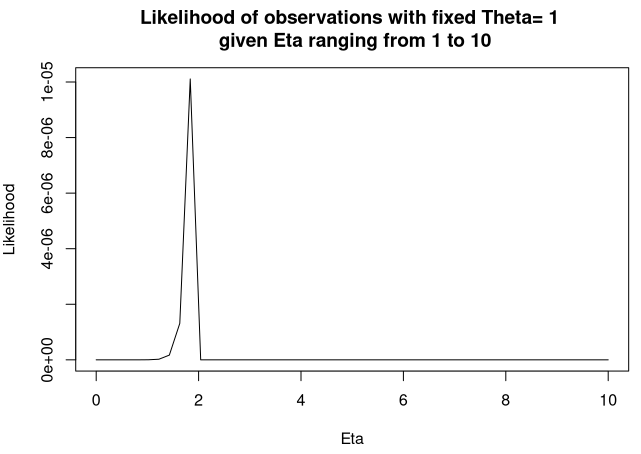

### Question 1.c

The definition of $\hat{\eta}$ could have been more explicit, especially with regards to how it relates, in methodology, to the computation of a MLE for a [uniform distribution](https://math.stackexchange.com/questions/411145/maximum-likelihood-estimation-of-a-b-for-a-uniform-distribution-on-a-b).

### Question 1.d

Of note, most $\eta$ used in the tutorial were integers compared to the small $\eta$ foun din the correction.

### Question 1.e

The different graphs should have been commented to explain that increasing MLEs for $\theta$ should indicate an increasing spiking rate. Furthermore, the scale effect between $\theta$ and $\eta$ results in the MLE of $\eta$ being squished to a line. $\eta$ should have been displayed with an inflated value to be visually interesting to look at.

### Question 1.f

*Not completed*

# Question 2

### Question 2.a

Explanation is okay, just very verbose. It could have been condensed.

### Question 2.b

### Question 2.c

### Question 2.d

### Question 2.e

*Not completed*